# Ad Exposure on Instagram: A Visual Story

Jason Thaing

## Introduction

This visual data story explores the experience of Instagram users during 5-minute scrolling sessions. Each session was logged using a Google Form and includes the number of ads seen, the most common ad category, time of day, and the device used. In total, 42 scrolling sessions were recorded.

The goal was to investigate whether ad exposure varies across different contexts — such as time of day, device type, or user behaviour.

### Google Form

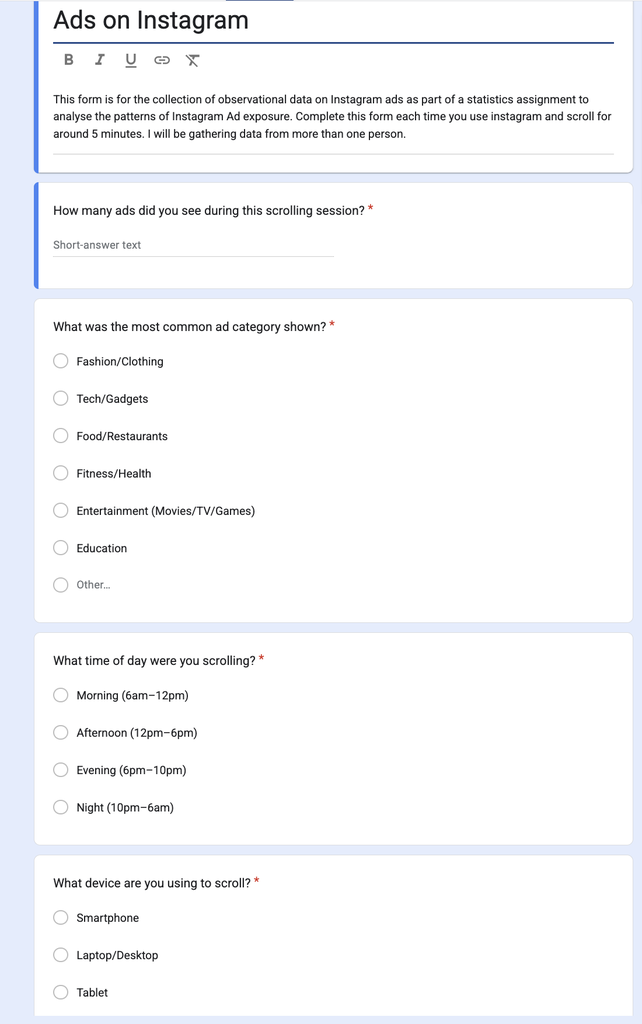

From my previous form, I added a new section asking what type of device was used during the Instagram session (e.g. smartphone, tablet, or desktop/laptop). I included this because the layout and ad delivery on Instagram can be dis-similar on each device. For example, users on smartphones may encounter more frequent or differently formatted ads compared to those on a desktop. By recording this detail, I’ll be more able to explore whether device type influences the number or type of ads observed.

## What Time of Day Has the Most Ads?

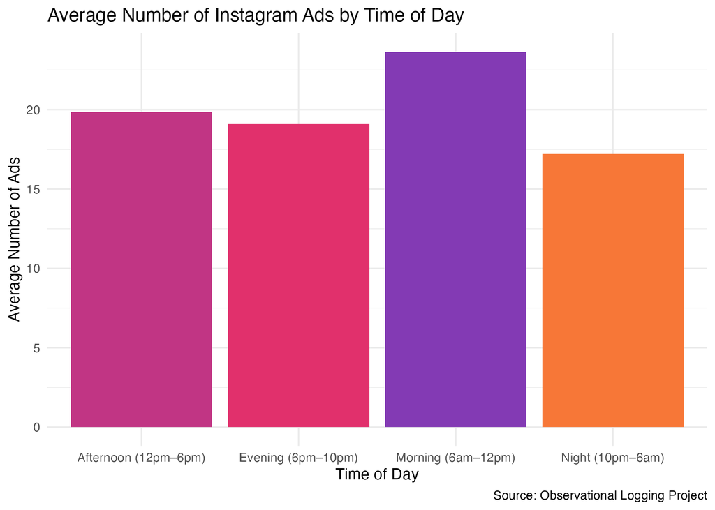

Bar chart showing average number of ads seen across different times of day

Users reported different ad loads depending on the time of day. Sessions during **Morning (6am–12pm)** and **Afternoon (12pm–6pm)** periods tended to have higher ad counts, indicating that Instagram may push more ad content when users are most active. On average, 20.3 ads were shown during each 5-minute scroll.

## Do Devices Affect What Ads Are Shown?

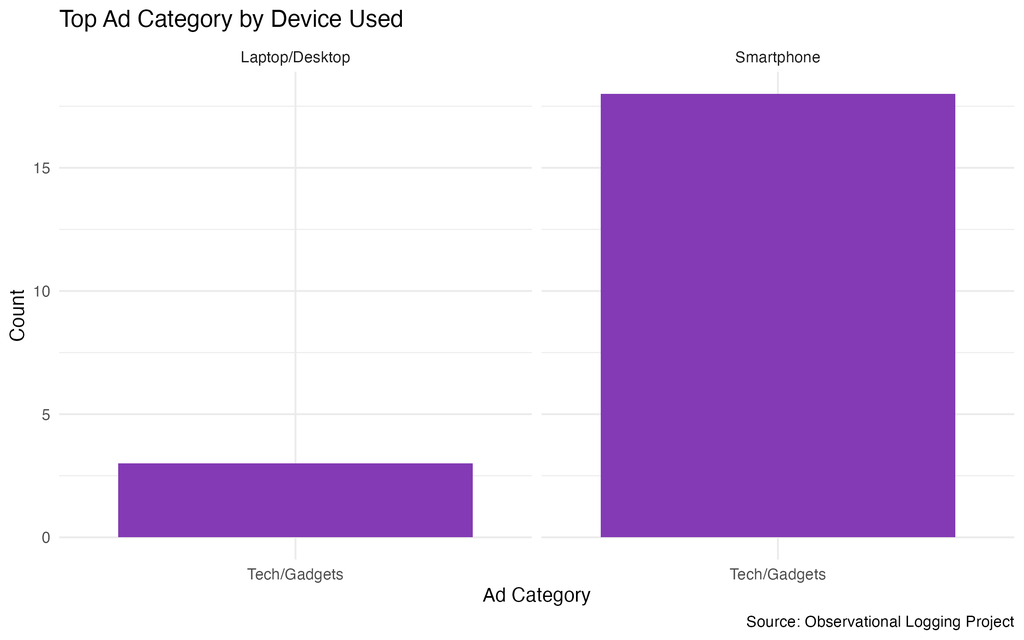

Facet bar chart showing most common ad category per device used

## Are Ads Increasing Over Time?

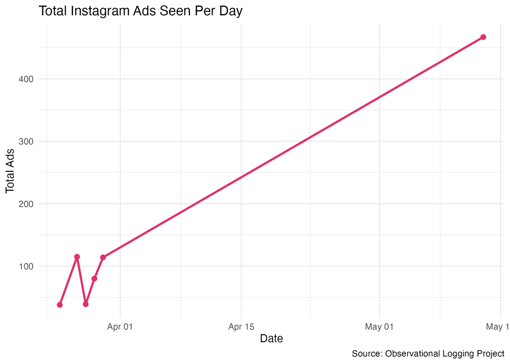

Line chart showing total ads seen per day over time

## Conclusion

All plots were created using `ggplot2`, and code used only STATS 220 techniques. The colour palette and styling were designed to reflect Instagram’s brand identity.